*Notebook by Daniyal Nathani*

# Image classification using CNNs

## Description

Data Description: You are provided with a dataset of images of plant seedlings at various stages of grown. Each image has a filename that is its unique id.

The dataset comprises 12 plant species. The goal of the project is to create a classifier capable of determining a plant's species from a photo.

Can you differentiate a weed from a crop seedling?  
The ability to do so effectively can mean better crop yields and better stewardship of the environment.

## Objective:

The main objective of the project is to: Build a CNN classifier that can determine what species a seedling is based on the image.

## Objective Insight and Analysis

We can effectively yield better crop results and maintain the environment if we can determine what kind of plant is growing from a picture!

## Data Description

The dataset can be download from Olympus. The data file names are:

- images.npy
- Label.csv

# Importing Libraries

```python
#Reading the training images from the path and labelling them into the given categories
import numpy as np
import pandas as pd
import matplotlib.pyplot as plt
import cv2
import os
import seaborn as sns # for data visualization
import tensorflow as tf
import keras
from tensorflow.keras.models import Sequential #sequential api for sequential model
from tensorflow.keras.layers import Dense, Dropout, Flatten #importing different layers
from tensorflow.keras.layers import Conv2D, MaxPooling2D, BatchNormalization, Activation, Input, LeakyReLU,Activation
from tensorflow.keras import backend as K
from tensorflow.keras.utils import to_categorical #to perform one-hot encoding
from keras.layers import Dense, Dropout, Flatten, Conv2D, MaxPool2D
from keras.optimizers import RMSprop,Adam #optimiers for optimizing the model
from keras.callbacks import EarlyStopping  #regularization method to prevent the overfitting
from keras.callbacks import ModelCheckpoint
from tensorflow.keras.models import Sequential, Model
from tensorflow.keras import losses, optimizers
from keras.utils import np_utils
from sklearn import preprocessing
from sklearn.model_selection import train_test_split
from sklearn.metrics import confusion_matrix
import itertools
from keras.preprocessing.image import ImageDataGenerator
```

# Loading the Data

```python
img_array = np.load('images.npy')
```

```python
labels = pd.read_csv("Labels.csv")
```

# Quick analysis on data shapes

```python
print('Shape of image array data is: ', img_array.shape)

print('Min and Max values are: ', img_array.min(), ' - ', img_array.max())

print('\n\nShape of labels data is: ', labels.shape)
```

```
Shape of image array data is:  (4750, 128, 128, 3)
Min and Max values are:  0  -  255


Shape of labels data is:  (4750, 1)
```

> There are 4750 pictures with the height, weight, and depth accordingly

> The labels data has one column that describes the type of plant seedling it is

# Categorical Analysis - What species and how many of each?

```python
labels
```

|  | Label |
| --- | --- |
| 0 | Small-flowered Cranesbill |
| 1 | Small-flowered Cranesbill |
| 2 | Small-flowered Cranesbill |
| 3 | Small-flowered Cranesbill |
| 4 | Small-flowered Cranesbill |
| ... | ... |
| 4745 | Loose Silky-bent |
| 4746 | Loose Silky-bent |
| 4747 | Loose Silky-bent |
| 4748 | Loose Silky-bent |
| 4749 | Loose Silky-bent |

4750 rows × 1 columns

```python
labels.isnull().sum()
```

```
Label    0
dtype: int64
```

> Had to check to for nulls!

```python
categories = labels.Label.unique()
categories
```

```
array(['Small-flowered Cranesbill', 'Fat Hen', 'Shepherds Purse',
       'Common wheat', 'Common Chickweed', 'Charlock', 'Cleavers',
       'Scentless Mayweed', 'Sugar beet', 'Maize', 'Black-grass',
       'Loose Silky-bent'], dtype=object)
```

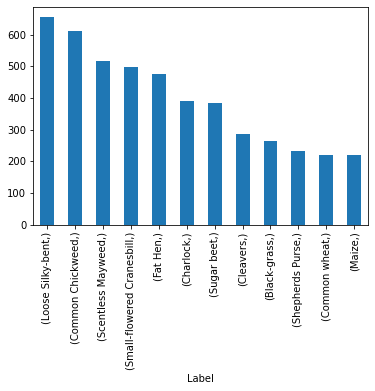

```python
labels.value_counts().plot(kind='bar')
```

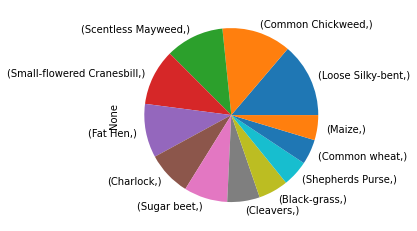

```python
labels.value_counts().plot(kind='pie')
```

These two graphs show us the distribution of the different seedling categories. They aren't too imbalanced but there is some slight imbalance with Loose Silky beny and Maize types.

# Random Pictures visualized

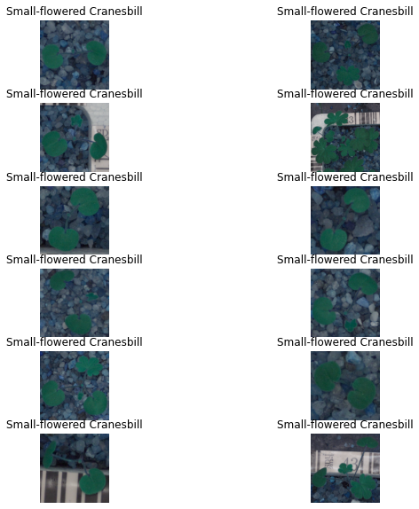

```python
figure = plt.figure(figsize=(10,10))
for i in range(12):
    plt.subplot(6, 2, i + 1)
    plt.axis("off")
    plt.title(labels.iloc[i][0])# labels.['Label'][i]
    plt.imshow(img_array[i].squeeze())
```

# Visualizing an Image from Each Category

```
This seedling is a Small-flowered Cranesbill
```

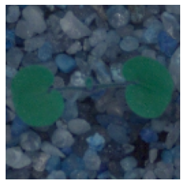

```
This seedling is a Fat Hen
```

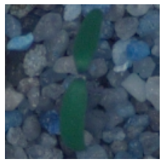

```
This seedling is a Shepherds Purse
```

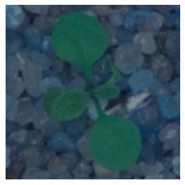

```
This seedling is a Common wheat
```

[figure not shown]

```
This seedling is a Common Chickweed
```

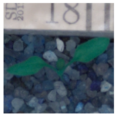

```
This seedling is a Charlock
```

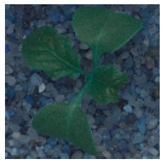

```
This seedling is a Cleavers
```

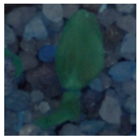

```
This seedling is a Scentless Mayweed
```

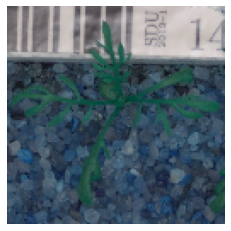

```
This seedling is a Sugar beet
```

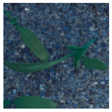

```
This seedling is a Maize
```

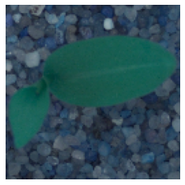

```
This seedling is a Black-grass
```

[figure not shown]

```
This seedling is a Loose Silky-bent
```

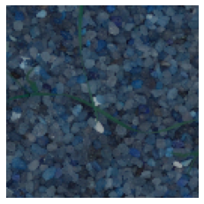

```python
prev_label = ' '
for i in range(len(labels)):
  label = labels.iloc[i][0]
  if label != prev_label:
    img = img_array[i]
    print('This seedling is a', label)
    plt.imshow(img)
    plt.axis('off')
    plt.show()
    prev_label = label
```

```python
num_categories = len(categories)
num_categories
```

```
12
```

> There are 12 categories. We need to keep this in mind as we need to make sure the shapes are all correct and the CNN has the right number of outputs!

## Plotting the Mean Image of each category!

```python
idx_sfc = labels.index[labels['Label'] == 'Small-flowered Cranesbill'].tolist()
idx_fathen = labels.index[labels['Label'] == 'Fat Hen'].tolist()
idx_shepherds = labels.index[labels['Label'] == 'Shepherds Purse'].tolist()
idx_wheat = labels.index[labels['Label'] == 'Common wheat'].tolist()
idx_chickweed = labels.index[labels['Label'] == 'Common Chickweed'].tolist()
idx_charlock = labels.index[labels['Label'] == 'Charlock'].tolist()
idx_cleaver = labels.index[labels['Label'] == 'Cleavers'].tolist()
idx_mayweed = labels.index[labels['Label'] == 'Scentless Mayweed'].tolist()
idx_sugarbeet = labels.index[labels['Label'] == 'Sugar beet'].tolist()
idx_maize = labels.index[labels['Label'] == 'Maize'].tolist()
idx_blkgrass = labels.index[labels['Label'] == 'Black-grass'].tolist()
idx_loosesb = labels.index[labels['Label'] == 'Loose Silky-bent'].tolist()
```

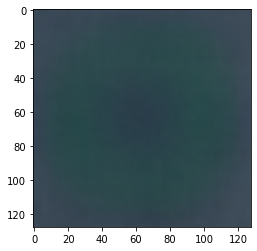

```python
mean_sfc = img_array[idx_sfc].mean(axis=0)
plt.imshow(mean_sfc.astype(np.uint8))
```

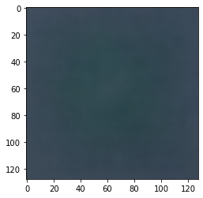

```python
mean_fathen = img_array[idx_fathen].mean(axis=0)
plt.imshow(mean_fathen.astype(np.uint8))
```

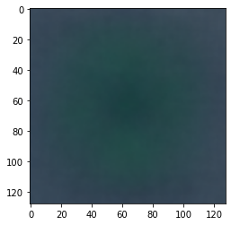

```python
mean_shepherds = img_array[idx_shepherds].mean(axis=0)
plt.imshow(mean_shepherds.astype(np.uint8))
```

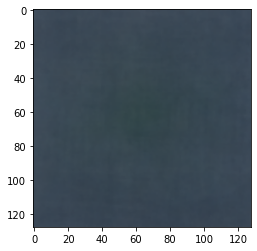

```python
mean_wheat = img_array[idx_wheat].mean(axis=0)
plt.imshow(mean_wheat.astype(np.uint8))
```

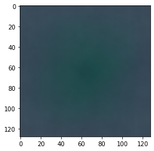

```python
mean_chickweed = img_array[idx_chickweed].mean(axis=0)
plt.imshow(mean_chickweed.astype(np.uint8))
```

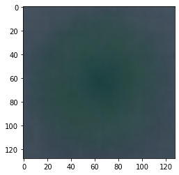

```python
mean_charlock = img_array[idx_charlock].mean(axis=0)
plt.imshow(mean_charlock.astype(np.uint8))
```

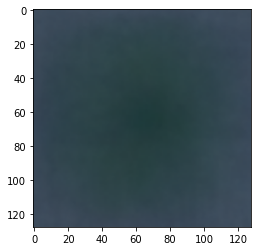

```python
mean_cleaver = img_array[idx_cleaver].mean(axis=0)
plt.imshow(mean_cleaver.astype(np.uint8))
```

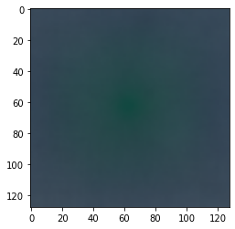

```python
mean_mayweed = img_array[idx_mayweed].mean(axis=0)
plt.imshow(mean_mayweed.astype(np.uint8))
```

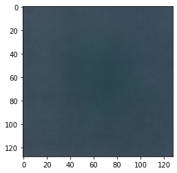

```python
mean_sugarbeet = img_array[idx_sugarbeet].mean(axis=0)
plt.imshow(mean_sugarbeet.astype(np.uint8))
```

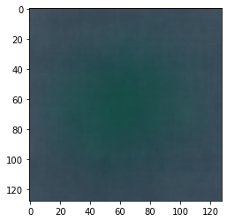

```python
mean_maize = img_array[idx_maize].mean(axis=0)
plt.imshow(mean_maize.astype(np.uint8))
```

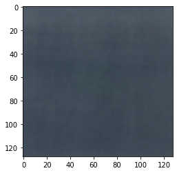

```python
mean_blkgrass = img_array[idx_blkgrass].mean(axis=0)
plt.imshow(mean_blkgrass.astype(np.uint8))
```

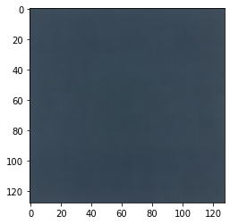

```python
mean_loosesb = img_array[idx_loosesb].mean(axis=0)
plt.imshow(mean_loosesb.astype(np.uint8))
```

> The mean images of each class seem to be so blurry. I would assume it is because of the background contributing to the average image while it is not a major part of what needs to be evaluated. We can see how certain categories show more green, different shades of green, and we are also able to make out some shapes.

> These are features that can be used when applying different preprocessing and data augmentation methods to really fine tune the model to the best client needs.